# Class 15: Analysis of Covariance (ANCOVA)

Hughes/Fisher

## What is ANCOVA?

In the most general sense, ANCOVA can be thought of as a regression problem that contains both numeric and categorical predictors. This isn’t exactly what it really means, however – in its origin, ANCOVA was a technique for investigating the effect of a factor on a response variable (this could be from a designed experiment or an observational study) after adjusting for the impact of some measured predictor variable, called a **covariate**.

For example, consider a weight loss study comparing the effects of two different diets on weight loss. We randomly assign one of the two diets to each of the subjects; they participate in their assigned diet, and then their weight loss is measured after 12 weeks. In such a scenario, we might want to use a subject-specific fitness measure (like BMI) as a **covariate** in the analysis. It is possible that the effectiveness of a diet (measured by weight loss) might be affected by the physical size of the subject. For example, someone with a higher BMI might have more potential for weight loss regardless of the diet they are on. So, it makes sense to account for this in the regression by also modeling it alongside the categorical ‘Diet’ factor. By doing so, we are not necessarily interested in the effect ‘BMI’ might have on weight loss – all we are doing is recognizing that it *may* have an effect, so it is smart to account for it when modeling.

## Example: The effect of smoking on the birth weight of newborns

The data set `babies.RData` contains information on the birth weights of newborns and if the mother has a history of smoking or not. The weight of the mother at the time of delivery is also provided. The goal of the study is to investigate the hypothesis that smoking is associated with lower average birth weight in babies. Of course, the weight of the mother may also be a determining factor in baby weight, so the effect of smoking should be adjusted for this. This calls for an ANCOVA.

The variables are:

- `momwt` - Weight of the mother (in pounds) at the time of delivery
- `smoker` - Smoking status of the mother (a logical variable)
- `babywt` - Birth weight of a newborn (in ounces)

Note that the data already reside in an R workspace (i.e. it is not in a .csv or .txt file), so we use the `load()` function in R. The workspace data already has the name `babies`:

```r
load("babies.Rdata")
head(babies)
```

```
##   momwt smoker babywt
## 1   100  FALSE    120
## 2   135  FALSE    113
## 3   115   TRUE    128
## 4   190   TRUE    123
## 5   125   TRUE    108
## 6    93   TRUE    136
```

### EDA

Birth weight (`babywt`) is the response variable here. Let’s create a scatterplot of birth weight vs. weight of the mother by smoking status.

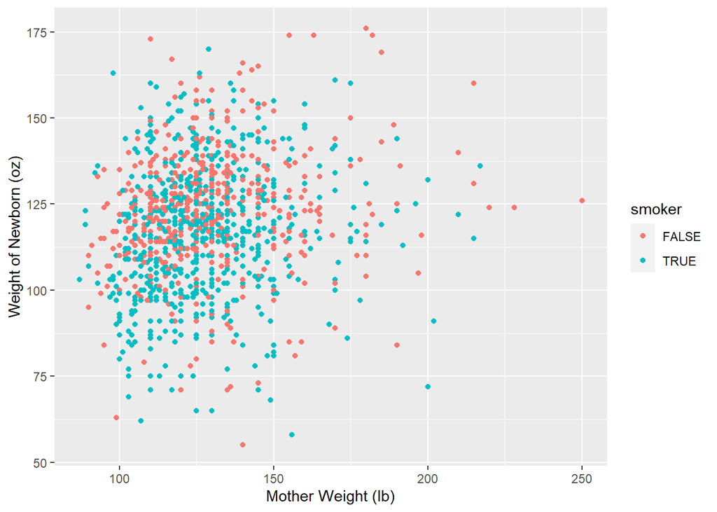

```r
edaplot <- ggplot(babies, aes(x=momwt, y=babywt, color=smoker)) +
  geom_point() +
  xlab("Mother Weight (lb)") +
  ylab("Weight of Newborn (oz)")
edaplot
```

First we see there is a lot of data here, and it is hard to distinguish between the smokers and non-smoking mothers. Let’s add a regression line for each smoking status to see the linear trends suggested by the data:

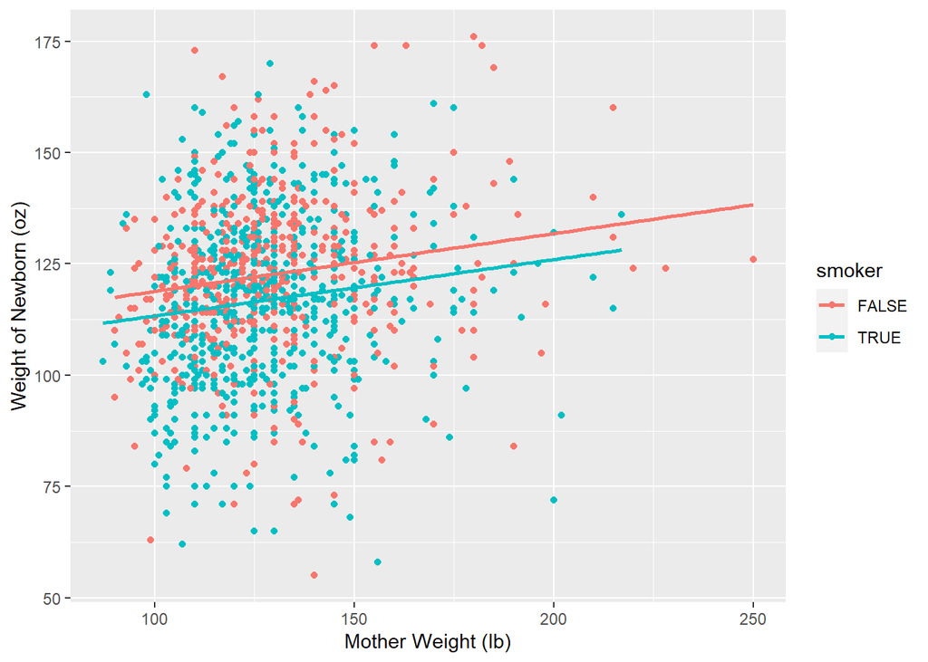

```r
edaplot +
  geom_smooth(method="lm", se=FALSE)
```

*INTERPRETATION:* There appears to be some effect due to the weight of the mother, namely that heavier women generally birth heavier babies (positive slope). This effect appears here to be nearly identical between smoking and non-smoking mothers (the two trend lines are nearly parallel – equal slopes). **In other words, there doesn’t appear to be any interaction to speak of between smoking status and weight of the mother in determining the mean baby weight.** However, we will want to confirm if this is the case with a formal test of hypothesis.

Of key interest is the vertical gap *between* the trend lines of smokers and non-smokers. There appears to be some consistent detrimental effect of smoking on the birth weight of babies, regardless of the weight of the mother.

### ANCOVA MODEL 1: Interaction Model

When we write out such a model, you will see the road map as to what the model’s $\beta$-coefficients actually represent in context. The interaction model is given by:

$$BabyWt = \beta_0 + \beta_1(MomWt) + \beta_2(I_{Smoker}) + \beta_3(MomWt*I_{Smoker}) + \varepsilon$$

where the variable $I_{Smoker}$ is 1 if the mother is a smoker, and 0 if not.

**ASIDE**. Note that the R variable `smoker` is actually a **logical variable** in the data set:

```r
class(babies$smoker)
```

```
## [1] "logical"
```

Internally, a logical variable in R has values `TRUE` and `FALSE` (you saw that in the scatterplots above), but when handling such variables arithmetically, R treats `TRUE` as 1 and `FALSE` as 0.

So what does this model look like under each of the `smoker` scenarios? Let’s check:

$$\begin{array}{ccc}
\hline
\textbf{Smoking Status} & \mathbf{I_{Smoker}} & \textbf{Model for mean response} \\
\hline
FALSE\ & 0 & \mu_{Non-smoker} = \beta_0 + \beta_1(MomWt) + \beta_2(0) + \beta_3(MomWt*0) = \beta_0 + \beta_1(MomWt) \\
TRUE\ & 1 & \mu_{Smoker} = \beta_0 + \beta_1(MomWt) + \beta_2(1) + \beta_3(MomWt*1) = (\beta_0 + \beta_2) + (\beta_1 + \beta_3)(MomWt) \\
\hline
\end{array}$$

Brilliant! A closer inspection will now reveal what each of this model’s $\beta$-parameters represents in context:

- $\beta_0$ represents the intercept of the line for non-smoking mothers; or, the mean weight of babies born to non-smoking mothers who weigh 0 pounds. **Clearly meaningless in context.**
- $\beta_1$ represents the slope of the line for non-smoking mothers; or, the change in mean weight of babies born to non-smoking mothers for each additional pound of weight of the mother.
- $\beta_2$ represents the **change** in the intercept of the line from non-smoking mothers to smoking mothers; or, the **change** in the mean weight of babies due to smoking, but specific to mothers weighing 0 pounds. **Also meaningless in context.**
- $\beta_3$ represents the **change** in the slope from ‘non-smoker’ to ‘smoker’ mothers.

The test for the interaction term $MomWt*I_{Smoker}$ is the critical test at this juncture. If we can show that $\beta_3 \neq 0$, then we will establish that the effect of smoking on baby weight **depends on the weight of the mother**. This is what an interaction between these variables means in this context.

So, we fit the model (check assumptions first before using the model for inference):

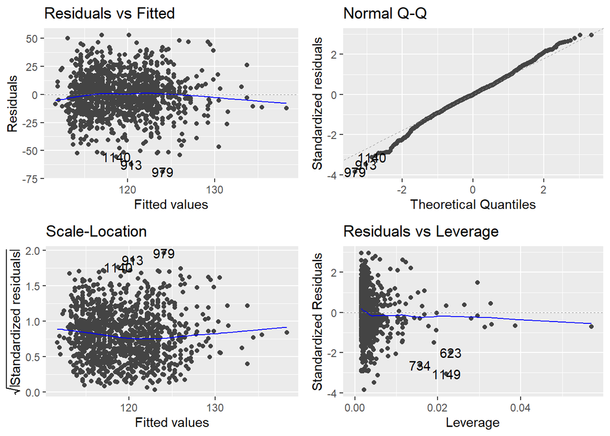

```r
ancova.model1 <- lm(babywt ~ momwt + smoker + momwt:smoker, data=babies)
autoplot(ancova.model1)
```

The assumptions look pretty good across the board. So, let’s look at the results:

```r
summary(ancova.model1)
```

```
##
## Call:
## lm(formula = babywt ~ momwt + smoker + momwt:smoker, data = babies)
##
## Residuals:
##     Min      1Q  Median      3Q     Max
## -69.025 -10.490  -0.359  11.055  53.008
##
## Coefficients:
##                    Estimate Std. Error t value Pr(>|t|)
## (Intercept)      105.843481   4.605936  22.980  < 2e-16 ***
## momwt              0.129865   0.034986   3.712 0.000215 ***
## smokerTRUE        -5.187454   6.485620  -0.800 0.423964
## momwt:smokerTRUE  -0.003227   0.049755  -0.065 0.948292
## ---
## Signif. codes:  0 '***' 0.001 '**' 0.01 '*' 0.05 '.' 0.1 ' ' 1
##
## Residual standard error: 17.91 on 1186 degrees of freedom
## Multiple R-squared:  0.04688,    Adjusted R-squared:  0.04447
## F-statistic: 19.45 on 3 and 1186 DF,  p-value: 2.607e-12
```

**This last result brings us to an important decision.** Because we have concluded that the effect of smoking is not tied to the weight of the mother, the interaction term can be deleted from the model, and we then have a **main-effects model**. Remember – simplify a regression model when you can, because this can make explanations of the results simpler!

### ANCOVA MODEL 2: Main-Effects-Only Model

It should be stated explicitly (again) that **we only choose to move to a main effects model because the interaction between the predictors under study was not significant.**

The main effects model just drops the interaction term(s). But, we must be aware of the ramifications on the interpretations of the $\beta$-coefficients that will result from doing so:

$$BabyWt = \beta_0 + \beta_1(MomWt) + \beta_2(I_{Smoker}) + \varepsilon$$
Model breakdown:

$$\begin{array}{ccc}
\hline
\textbf{Smoking Status} & \mathbf{I_{Smoker}} & \textbf{Model for mean response} \\
\hline
FALSE\ & 0 & \mu_{Non-smoker} = \beta_0 + \beta_1(MomWt) + \beta_2(0) = \beta_0 + \beta_1(MomWt) \\
TRUE\ & 1 & \mu_{Smoker} = \beta_0 + \beta_1(MomWt) + \beta_2(1) = (\beta_0 + \beta_2) + \beta_1(MomWt) \\
\hline
\end{array}$$

Note the differences in interpretations from before:

- $\beta_0$ now represents the intercept of the line for non-smoking mothers; or, the mean weight of babies born to non-smoking mothers weighing 0 pounds. Still meaningless in context.
- $\beta_1$ now represents the slope of the line for **either** non-smoking **or** smoking mothers; or, the change in mean weight of babies for each additional pound of weight of the mother, **regardless of whether or not the mother is a smoker**.
- $\beta_2$ now represents represents the **change** in the intercept of the line from non-smoking mothers to smoking mothers.

The test for $\beta_2$ addresses the main goal of the study. If we can show that $\beta_2 \neq 0$, then we will establish that there is an effect of smoking on baby weight **regardless of the weight of the mother**.

So, we fit the main effects model (check assumptions first):

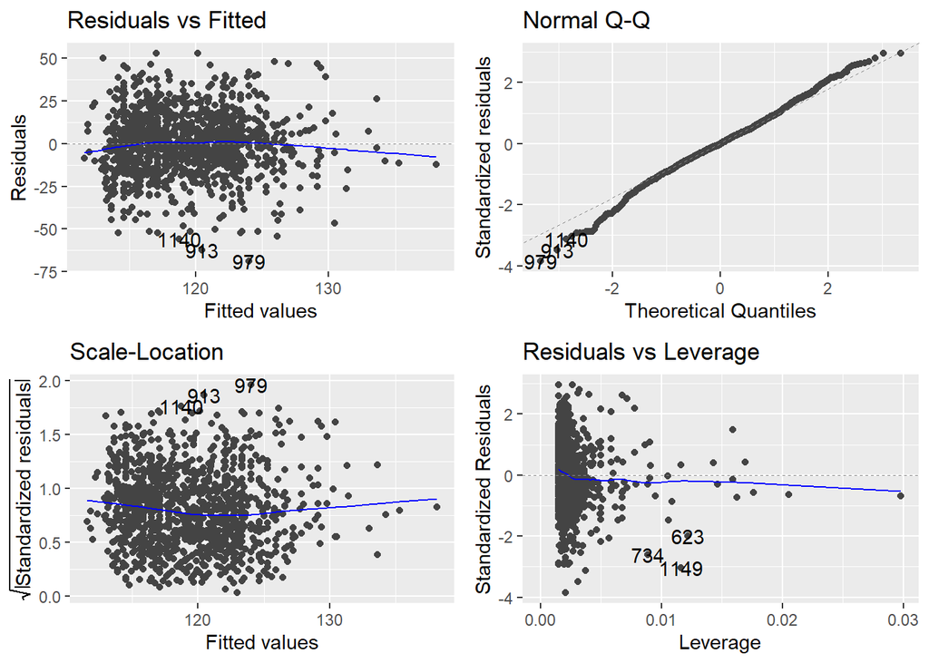

```r
ancova.model2 <- lm(babywt ~ momwt + smoker, data=babies)
autoplot(ancova.model2)
```

```r
summary(ancova.model2)
```

```
##
## Call:
## lm(formula = babywt ~ momwt + smoker, data = babies)
##
## Residuals:
##     Min      1Q  Median      3Q     Max
## -69.008 -10.510  -0.353  11.078  53.005
##
## Coefficients:
##              Estimate Std. Error t value Pr(>|t|)
## (Intercept) 106.05055    3.31885  31.954  < 2e-16 ***
## momwt         0.12827    0.02487   5.159 2.91e-07 ***
## smokerTRUE   -5.60264    1.04571  -5.358 1.01e-07 ***
## ---
## Signif. codes:  0 '***' 0.001 '**' 0.01 '*' 0.05 '.' 0.1 ' ' 1
##
## Residual standard error: 17.91 on 1187 degrees of freedom
## Multiple R-squared:  0.04688,    Adjusted R-squared:  0.04527
## F-statistic: 29.19 on 2 and 1187 DF,  p-value: 4.213e-13
```

Note the slight rise in the adjusted $R^2$ as compared to the interaction model. Here’s the test of interest:

- $H_0:\beta_2 = 0$ (smoking has **no** effect on mean baby weight (after adjusting for mother’s weight))
- $H_a:\beta_2 \neq 0$ (smoking **has** an effect on mean baby weight (after adjusting for mother’s weight))
- The test statistic is $t$ = -5.358, with a $p$-value of $10^{-7}$. We reject $H_0$. **Smoking has an effect on mean baby weight after adjusting for mother’s weight.**

**Estimate the effect.** We can look at the model’s estimate of $\beta_2$, which is $\hat{\beta}_2$ = -5.602. This means that we estimate that smoking mothers will birth babies whose mean weight is 5.6 ounces *lower* than that of non-smiking mothers. Better yet, we can establish a confidence interval for this:

```r
confint(ancova.model2)
```

```
##                   2.5 %      97.5 %
## (Intercept) 99.53908592 112.5620143
## momwt        0.07948405   0.1770551
## smokerTRUE  -7.65429432  -3.5509838
```

*INTERPRETATION:* We can be 95% confident that smoking will lower the true mean birth weight of babies by between 3.55 to 7.65 ounces, regardless of the weight of the mother.

**Using the model for response prediction.** Even though the model’s $R^2$ is not very impressive, we can still use the model for prediction if we are satisfied that it is a good model. Just be aware that any predictions or estimation of the response `babywt` may have some lack of precision.

Let’s use the main effects ANCOVA model to find and interpret separate 95% confidence intervals for

- the true mean birth weight of newborns of all mothers of average weight who have a history of smoking
- the true mean birth weight of newborns of all mothers of average weight who have no smoking history.

First, determine the mean weight of mothers in the sample (as our estimate of “average mother weight”):

```r
babies %>%
  summarize(MeanWeight = mean(momwt))
```

```
##   MeanWeight
## 1    128.537
```

Now, the two CIs:

```r
predict(ancova.model2, newdata=data.frame(momwt=128.54, smoker=TRUE), interval="confidence")
```

```
##        fit      lwr      upr
## 1 116.9357 115.5662 118.3051
```

```r
predict(ancova.model2, newdata=data.frame(momwt=128.54, smoker=FALSE), interval="confidence")
```

```
##        fit      lwr      upr
## 1 122.5383 121.0125 124.0641
```

*INTERPRETATIONS:*

- We can be 95% confident that the true mean birth weight of babies from mothers of average weight with a smoking history is between 115.5 oz to 118.3 oz.
- We can be 95% confident that the true mean birth weight of babies from mothers of average weight with no smoking history is between 121.0 oz to 124.0 oz.

## In-class Assignment

This assignment is structured to achieve two goals:

- Review some important elements from design - The material from the beginning of the class will hang around.
- Perform an ANCOVA analysis.

# Study

The skin smoothing effects of three different liquid gels were randomly assigned to 60 mature women (20 for each treatment). Treatment applications were performed twice a day over a period of 4 weeks, and the skin roughness parameter (Rz) of all test participants was determined at the beginning (pre-treatment) and at the end of the study (post-treatment) using a computer-aided laser profilometry. The three different liquid gels included a control, a liquid gel moisturizer and another liquid gel that included a 1% concentration of Dead Sea minerals. The researchers want to know the relationship between treatments effects and skin smoothness/roughness.

**Source:** Ma’or Z., Yehuda, S. and Voss, W. (1997), Skin smoothing effects of Dead Sea minerals: comparative profilometric evaluation of skin surface. *International Journal of Cosmetic Science*, 19: 105-110.

Some initial data processing is provided below:

```r
skin_softness <- read.csv("deadseaminerals.csv") %>%
  mutate(trt_Grp = factor(trt_Grp, levels=c(3,1,2), labels=c("Control", "Gel", "Gel w/ minerals")))
```

# Part 1 - Design elements

## Question 1

You should note that this is a designed experiment.

How many factors are present in this experiment? How many factor levels are there? How many treatments?

**Factors: Liquid gel** **Factor Levels: Three different liquid gels** **Treatment: Time (before and after)**

## Question 2

You should note that for each subject (i.e. each experimental unit) we have a pre and post treatment measure; so this is not a simple One-Way ANOVA. What are some of the potential model types we covered near the beginning of class that can be used for this analysis?

**Repeated measures since they are taking multiple measurements of dependent results over time.**

# Part 2 - ANOVA Analysis

We will perform some data processing and perform a one-way ANOVA on this data.

## Question 3

In the code chunk below, we create a new variable in the dataset that is the difference between the post-treatment roughness and pre-treatment roughness of the skin samples, followed by the construction of side-by-side boxplots, with overlaid means, for the difference between post and pre treatment skin roughness as a function of the three skin softness treatments.

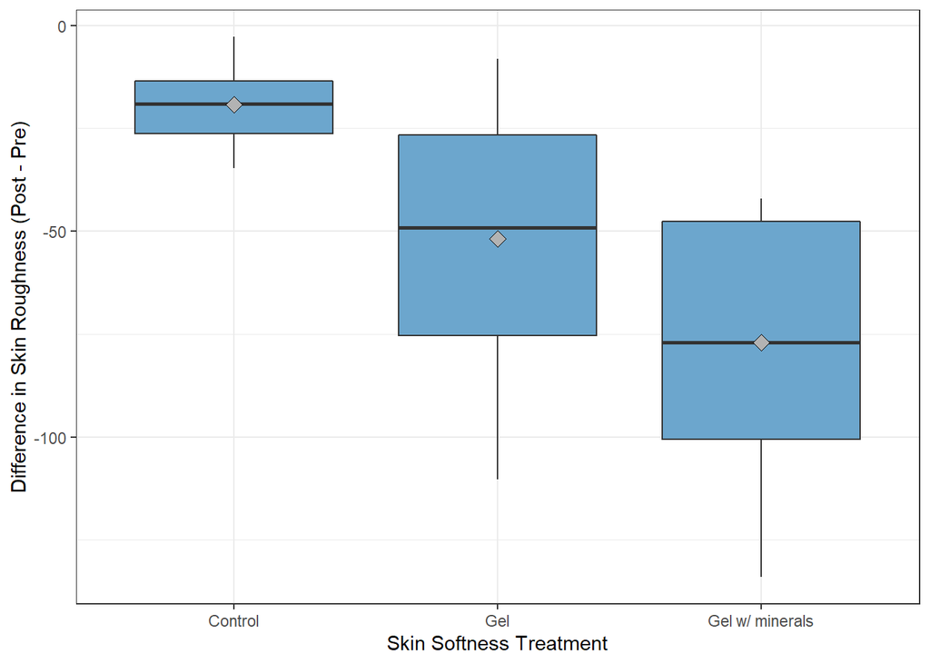

```r
skin_softness <- skin_softness %>%
  mutate(Pre_Post_Diff = post_rough - pre_rough)

ggplot(skin_softness, aes(x=trt_Grp, y=Pre_Post_Diff)) +
  geom_boxplot(fill="skyblue3") +
  stat_summary(fun="mean", geom="point", shape=23, fill="gray70", size=3 ) +
  labs(y="Difference in Skin Roughness (Post - Pre)",
       x="Skin Softness Treatment") +
  theme_bw()
```

```r
head(skin_softness)
```

```
##   trt_Grp pre_rough post_rough Pre_Post_Diff
## 1     Gel    121.10      76.30        -44.80
## 2     Gel    375.40     265.10       -110.30
## 3     Gel    138.05      82.92        -55.13
## 4     Gel    114.85      91.75        -23.10
## 5     Gel    263.91     175.32        -88.59
## 6     Gel    255.88     152.54       -103.34
```

Perform an EDA by making some assessments/observations about these data.

**We can see that the control has a les varience versus the gel and gel w/ minerals varience. The control is on average less smoooth than the two other factor levels.**

## Question 4

Perform a One-Way ANOVA analysis on the difference of post and pre-treatment skin roughness as a function of the different skin care treatments.

*Recall:* a complete analysis includes

- fitting the ANOVA model,
- checking the assumptions,
- looking at the overall ANOVA summary output, and
- performing any follow-up multiple comparisons (*hint*: we have a control group! Use Dunnett’s method).

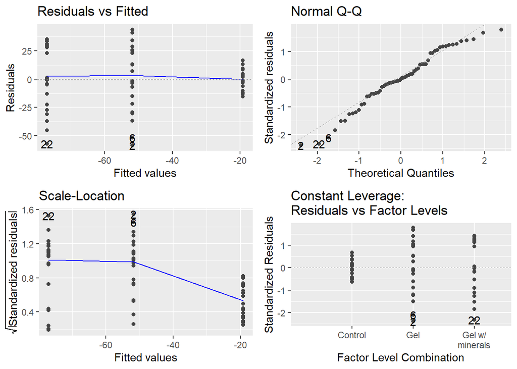

```r
# Create one-way anova
skin_softness.anova <- aov(Pre_Post_Diff ~ trt_Grp, data=skin_softness)
autoplot(skin_softness.anova)
```

```r
summary(skin_softness.anova)
```

```
##             Df Sum Sq Mean Sq F value   Pr(>F)
## trt_Grp      2  33666   16833   26.79 6.27e-09 ***
## Residuals   57  35813     628
## ---
## Signif. codes:  0 '***' 0.001 '**' 0.01 '*' 0.05 '.' 0.1 ' ' 1
```

**We can see that the normality Q-Q plot is veering off of the line making the normality assumption if-fy. As-well as the scale location plot not being linear, thus the constant variance assumption could be broken here.**

**With 2 and 57 degrees of freedom and a P-value of 6.27e-09 this tells us that there is a difference between at least one of the gels.**

```r
# Perform multiple comparisons
skin_softness.mc <- emmeans(skin_softness.anova, "trt_Grp")
contrast(skin_softness.mc, "trt.vs.ctrl", ref=1)
```

```
##  contrast                    estimate   SE df t.ratio p.value
##  Gel - Control                  -32.6 7.93 57  -4.113  0.0003
##  (Gel w/ minerals) - Control    -57.9 7.93 57  -7.301  <.0001
##
## P value adjustment: dunnettx method for 2 tests
```

**We can see that the p-value for both factors comparing it to the control are below 0.05. The p-value for Gel - Control is 0.0003 and the p-value for (Gel w/ minerals) - Control is <.0001. Thus, we can see that both have a major difference in skin smoothness compared to the control.**

# Part 3 - ANCOVA

If you completed the above analysis correctly, you should note that the different treatments influence the difference between post and pre-treatment skin roughness. However, that analysis is potentially flawed:

> What if different skin treatments were more (or less) effective on certain types of skin roughness?

For example, what if the control was just as effective as the Gels when skin wasn’t that rough, but that with rougher skin, one of the Gel’s is more effective.

You should note that the above analysis does *not* allow for that sort of question to be answered. By creating a difference variable for the response, we are implicitly handling the time element (the two repeated measures) and the block term (the within-subject effects) but we are also potentially disguising potential valuable information (e.g., maybe the Gel with Dead Sea concentrations is particularly effective on certain skin roughness measures, etc.).

## Question 5

Construct a scatterplot with overlaid regression lines (use `geom_smooth()` with the `method='lm'` option) where the $x$-axis is the pre-treatment skin roughness measure and the $y$-axis is the post-treatment skin roughness measure, and each point is colored by the different treatments. Describe the results and what the overlaid regression lines imply.

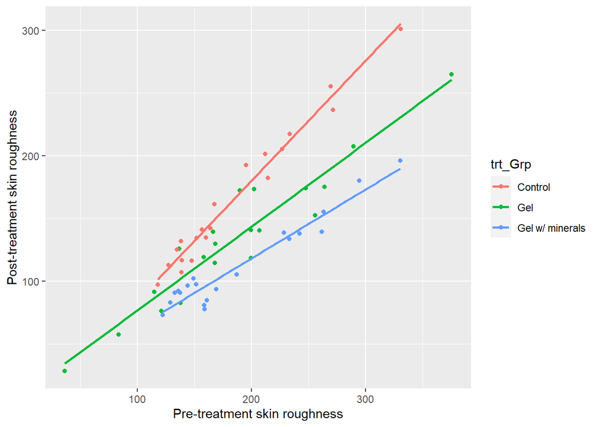

```r
edaplot_2 <- ggplot(skin_softness, aes(x=pre_rough, y=post_rough, color=trt_Grp)) +
  geom_point() +
  xlab("Pre-treatment skin roughness") +
  ylab("Post-treatment skin roughness") +
  geom_smooth(method="lm", se=FALSE)
edaplot_2
```

**We can see that each of the three controls have different slopes when looking at each factor level individually.**

## Question 6

Fit an ANCOVA model where the response is the post-treatment skin roughness, and the predictors include the pre-treatment skin roughness measure (the “covariate”), the treatment factor, **and** their interaction. Perform a residual analysis to assess the underlying assumptions. What do these findings imply about the results in question 4?

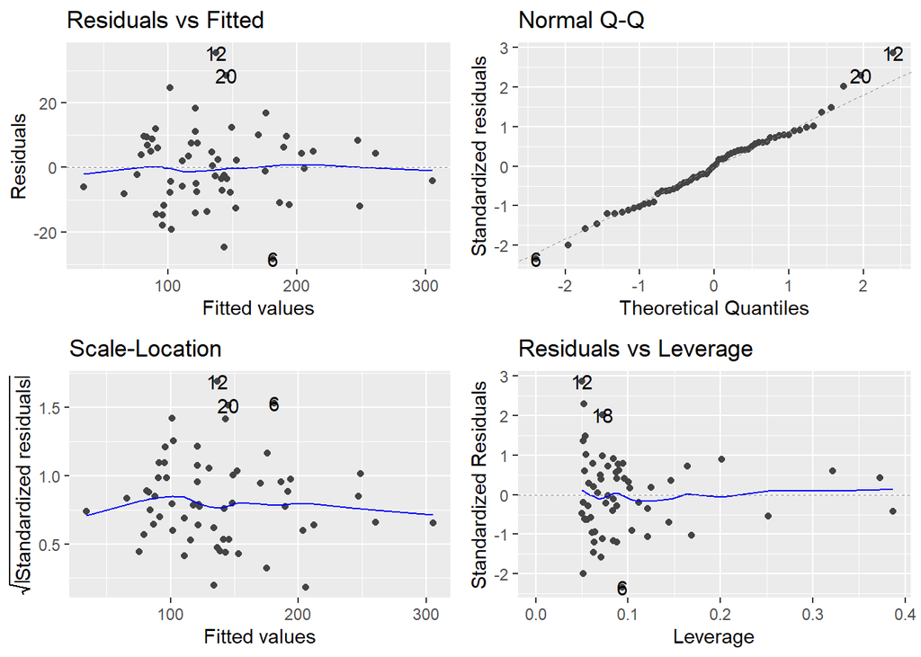

```r
skin_softness.ancova <- lm(post_rough ~ pre_rough + trt_Grp + pre_rough:trt_Grp, data=skin_softness)
autoplot(skin_softness.ancova)
```

**The ancova plot fits all assumptions. We can see the scale location and residual vs fitted plot is horizontal, thus, passing the assumption. The Q-Q plot sticks very close to the line, thus it fits the normality assumption.**

## Question 7

Provide the summary output from your ANCOVA model in question 6. Interpret the results of this model.

```r
summary(skin_softness.ancova)
```

```
##
## Call:
## lm(formula = post_rough ~ pre_rough + trt_Grp + pre_rough:trt_Grp,
##     data = skin_softness)
##
## Residuals:
##     Min      1Q  Median      3Q     Max
## -28.385  -7.771   0.046   7.394  35.485
##
## Coefficients:
##                                   Estimate Std. Error t value Pr(>|t|)
## (Intercept)                      -11.49790    9.78076  -1.176    0.245
## pre_rough                          0.95835    0.05061  18.937  < 2e-16 ***
## trt_GrpGel                        21.50163   12.41470   1.732    0.089 .
## trt_GrpGel w/ minerals            19.76608   13.54513   1.459    0.150
## pre_rough:trt_GrpGel              -0.29037    0.06337  -4.582 2.76e-05 ***
## pre_rough:trt_GrpGel w/ minerals  -0.40842    0.06913  -5.908 2.40e-07 ***
## ---
## Signif. codes:  0 '***' 0.001 '**' 0.01 '*' 0.05 '.' 0.1 ' ' 1
##
## Residual standard error: 12.71 on 54 degrees of freedom
## Multiple R-squared:  0.9477, Adjusted R-squared:  0.9429
## F-statistic: 195.8 on 5 and 54 DF,  p-value: < 2.2e-16
```

**Based on the result, each treatment gives a different difference softness in skin.**